# InVivoStat Single Measure Parametric Analysis

## Response

The Resp 1 response is currently being analysed by the Single Measures Parametric Analysis module.The response has been square root transformed prior to analysis.

## Scatterplot of the observed data (on the square root scale)

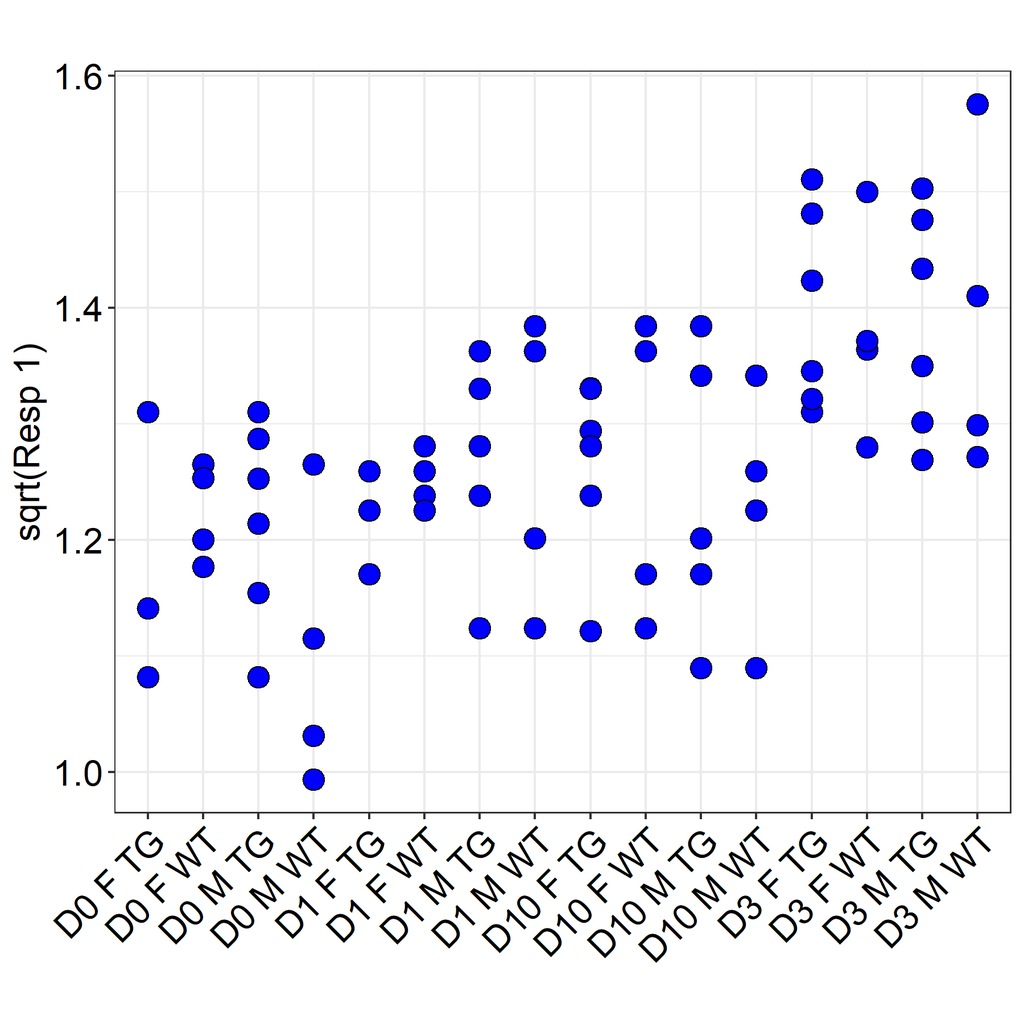

Tip: Use this plot to identify possible outliers.

## Analysis of variance (ANOVA) table

| Effect | Sums of squares | Degrees of freedom | Mean square | F-value | p-value |
| --- | --- | --- | --- | --- | --- |
| Blo ck1 | 0.001 | 1 | 0.001 | 0.08 | 0.7849 |
| Blo ck2 | 0.019 | 2 | 0.010 | 1.06 | 0.3523 |
| Treat1 | 0.449 | 3 | 0.150 | 16.33 | < 0.0001 |
| Treat2 | 0.000 | 1 | 0.000 | 0.03 | 0.8660 |
| Treat3 | 0.000 | 1 | 0.000 | 0.01 | 0.9119 |
| Treat1 * Treat2 | 0.018 | 3 | 0.006 | 0.64 | 0.5910 |
| Treat1 * Treat3 | 0.003 | 3 | 0.001 | 0.11 | 0.9530 |
| Treat2 * Treat3 | 0.014 | 1 | 0.014 | 1.49 | 0.2263 |
| Treat1 * Treat2 * Treat3 | 0.035 | 3 | 0.012 | 1.26 | 0.2976 |
| Residual | 0.541 | 59 | 0.009 |  |  |

Comment: ANOVA table calculated using a Type III model fit, see Armitage et al. (2001).

Conclusion: At the 5% level, there is a statistically significant overall difference between the levels of Treat1.

Tip: While it is a good idea to consider the overall tests in the ANOVA table, we should not rely on them when deciding whether or not to make pairwise comparisons.

## Model coefficients

|  | Estimate | Std. Error | t-value | p-value |
| --- | --- | --- | --- | --- |
| (Intercept) | 1.2647 | 0.0111 | 114.35 | < 0.0001 |
| Blo ck11 | -0.0030 | 0.0108 | -0.27 | 0.7849 |
| Blo ck21 | 0.0213 | 0.0156 | 1.37 | 0.1763 |
| Blo ck22 | -0.0039 | 0.0156 | -0.25 | 0.8033 |
| Treat11 | -0.0907 | 0.0196 | -4.62 | < 0.0001 |
| Treat12 | -0.0156 | 0.0190 | -0.82 | 0.4163 |
| Treat13 | -0.0178 | 0.0190 | -0.94 | 0.3524 |
| Treat21 | 0.0019 | 0.0111 | 0.17 | 0.8660 |
| Treat31 | 0.0012 | 0.0111 | 0.11 | 0.9119 |
| Treat11:Treat21 | 0.0125 | 0.0197 | 0.63 | 0.5285 |
| Treat12:Treat21 | -0.0232 | 0.0191 | -1.21 | 0.2297 |
| Treat13:Treat21 | 0.0150 | 0.0190 | 0.79 | 0.4336 |
| Treat11:Treat31 | 0.0074 | 0.0197 | 0.38 | 0.7078 |
| Treat12:Treat31 | -0.0096 | 0.0190 | -0.50 | 0.6172 |
| Treat13:Treat31 | -0.0018 | 0.0190 | -0.10 | 0.9238 |
| Treat21:Treat31 | -0.0135 | 0.0111 | -1.22 | 0.2263 |
| Treat11:Treat21:Treat31 | -0.0351 | 0.0197 | -1.78 | 0.0808 |
| Treat12:Treat21:Treat31 | -0.0022 | 0.0190 | -0.12 | 0.9068 |
| Treat13:Treat21:Treat31 | 0.0164 | 0.0190 | 0.86 | 0.3929 |

## Diagnostic plots

### Residuals vs. predicted plot

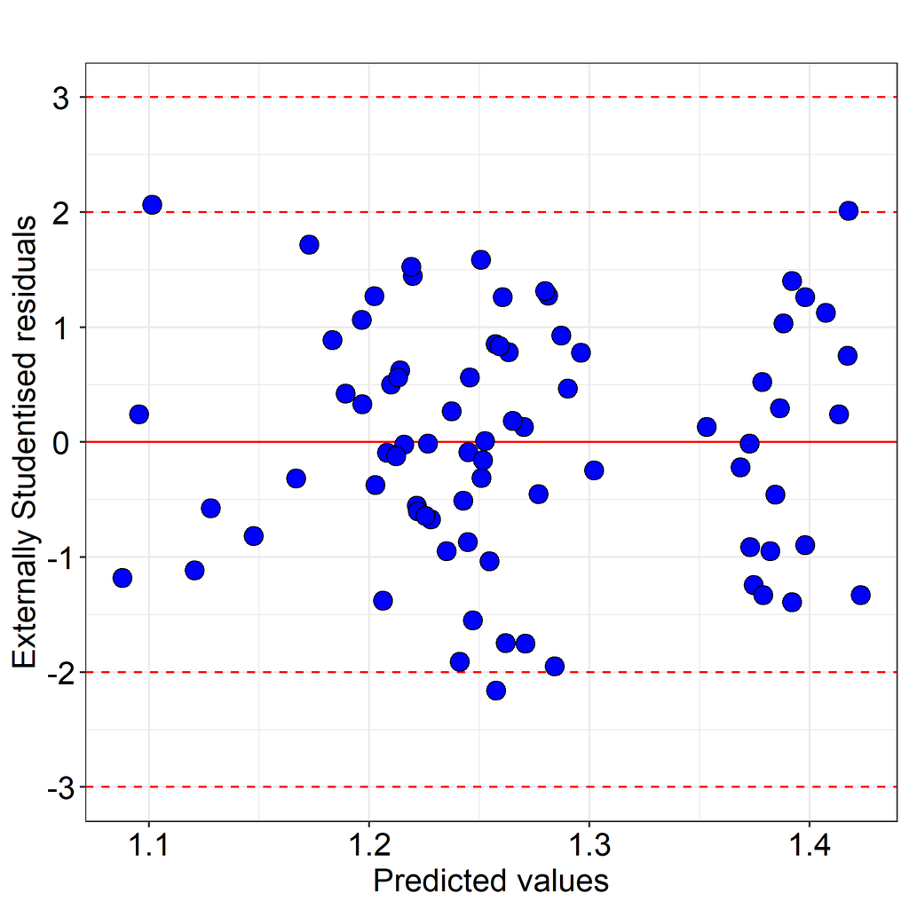

Tip: On this plot look to see if the spread of the points increases as the predicted values increase. If so the response may need transforming.

Tip: Any observation with a residual less than -3 or greater than 3 (SD) should be investigated as a possible outlier.

### Normal probability plot

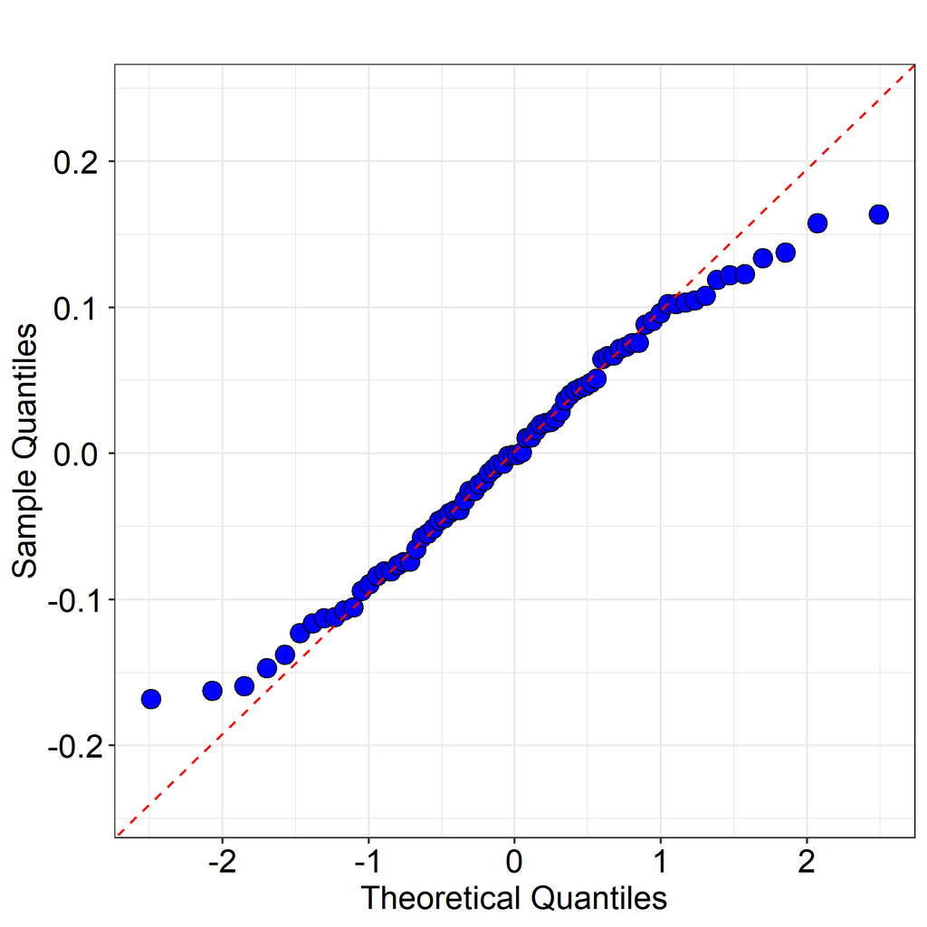

Tip: Check that the points lie along the dotted line. If not then the data may be non-normally distributed.

## Table of the least square (predicted) means with 95% confidence intervals

| Mean ID | Treat1 | Treat2 | Mean | Lower 95% CI | Upper 95% CI |
| --- | --- | --- | --- | --- | --- |
| 1 | D0 | F | 1.188 | 1.121 | 1.256 |
| 2 | D1 | F | 1.228 | 1.166 | 1.290 |
| 3 | D10 | F | 1.264 | 1.202 | 1.326 |
| 4 | D3 | F | 1.386 | 1.324 | 1.448 |
| 5 | D0 | M | 1.160 | 1.098 | 1.222 |
| 6 | D1 | M | 1.270 | 1.208 | 1.332 |
| 7 | D10 | M | 1.230 | 1.168 | 1.292 |
| 8 | D3 | M | 1.391 | 1.329 | 1.453 |

## Plot of the least square (predicted) means with 95% confidence intervals

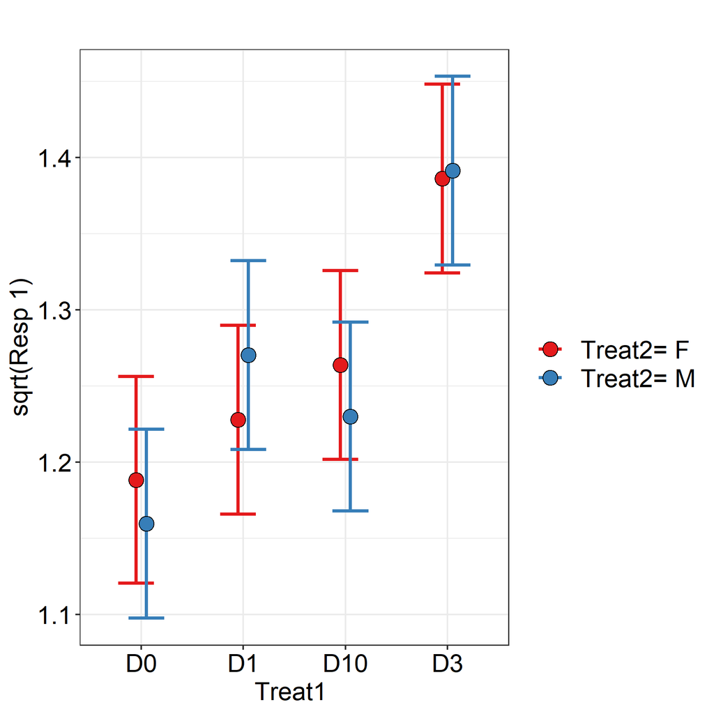

## All pairwise comparisons using Hochberg's procedure

| Comparison | Difference | Lower 95% CI | Upper 95% CI | Std error | p-value |
| --- | --- | --- | --- | --- | --- |
| D0,F - D1,F | -0.039 | -0.131 | 0.053 | 0.046 | 0.9613 |
| D0,F - D10,F | -0.075 | -0.167 | 0.017 | 0.046 | 0.9613 |
| D0,F - D3,F | -0.198 | -0.290 | -0.106 | 0.046 | 0.0015 |
| D0,F - D0,M | 0.029 | -0.063 | 0.121 | 0.046 | 0.9613 |
| D0,F - D1,M | -0.082 | -0.174 | 0.010 | 0.046 | 0.9613 |
| D0,F - D10,M | -0.042 | -0.133 | 0.050 | 0.046 | 0.9613 |
| D0,F - D3,M | -0.203 | -0.295 | -0.111 | 0.046 | 0.0011 |
| D1,F - D10,F | -0.036 | -0.123 | 0.052 | 0.044 | 0.9613 |
| D1,F - D3,F | -0.158 | -0.246 | -0.071 | 0.044 | 0.0137 |
| D1,F - D0,M | 0.068 | -0.019 | 0.156 | 0.044 | 0.9613 |
| D1,F - D1,M | -0.043 | -0.130 | 0.045 | 0.044 | 0.9613 |
| D1,F - D10,M | -0.002 | -0.090 | 0.086 | 0.044 | 0.9613 |
| D1,F - D3,M | -0.163 | -0.251 | -0.076 | 0.044 | 0.0104 |
| D10,F - D3,F | -0.123 | -0.210 | -0.035 | 0.044 | 0.1325 |
| D10,F - D0,M | 0.104 | 0.017 | 0.192 | 0.044 | 0.3060 |
| D10,F - D1,M | -0.007 | -0.094 | 0.081 | 0.044 | 0.9613 |
| D10,F - D10,M | 0.034 | -0.054 | 0.121 | 0.044 | 0.9613 |
| D10,F - D3,M | -0.128 | -0.215 | -0.040 | 0.044 | 0.1018 |
| D3,F - D0,M | 0.227 | 0.139 | 0.314 | 0.044 | < 0.0001 |
| D3,F - D1,M | 0.116 | 0.028 | 0.203 | 0.044 | 0.1744 |
| D3,F - D10,M | 0.156 | 0.069 | 0.244 | 0.044 | 0.0152 |
| D3,F - D3,M | -0.005 | -0.093 | 0.083 | 0.044 | 0.9613 |
| D0,M - D1,M | -0.111 | -0.198 | -0.023 | 0.044 | 0.2267 |
| D0,M - D10,M | -0.070 | -0.158 | 0.017 | 0.044 | 0.9613 |
| D0,M - D3,M | -0.232 | -0.319 | -0.144 | 0.044 | < 0.0001 |
| D1,M - D10,M | 0.040 | -0.047 | 0.128 | 0.044 | 0.9613 |
| D1,M - D3,M | -0.121 | -0.209 | -0.033 | 0.044 | 0.1390 |
| D10,M - D3,M | -0.161 | -0.249 | -0.074 | 0.044 | 0.0112 |

Conclusion: The following pairwise comparisons are statistically significant at the 5% level: (1) D0,F - D3,F, (2) D0,F - D3,M, (3) D1,F - D3,F, (4) D1,F - D3,M, (5) D3,F - D0,M, (6) D3,F - D10,M, (7) D0,M - D3,M, (8) D10,M - D3,M.

Warning: It is not advisable to draw statistical inferences about a factor/interaction in the presence of a significant higher-order interaction involving that factor/interaction.

Warning: This procedure makes an adjustment assuming you want to make all pairwise comparisons. If this is not the case then these tests may be unduly conservative. You may wish to use planned comparisons (using unadjusted p-values) instead, see Snedecor and Cochran (1989), or make a manual adjustment to the unadjusted p-values using the InVivoStat P-value Adjustment module.

Note: The confidence intervals quoted are not adjusted for multiplicity.

## Analysis description

The data were analysed using a 3-way ANOVA approach, with Treat1, Treat2 and Treat3 as the treatment factors and Blo ck1 and Blo ck2 as the blocking factors. This was followed by all pairwise comparisons between the predicted means of the Treat1 * Treat2 interaction using Hochberg's procedure, Hochberg (1988). The response was square root transformed prior to analysis to stabilise the variance.

For more information on the theoretical approaches that are implemented within this module, see Bate and Clark (2014).

## References

When referring to InVivoStat, please cite 'InVivoStat, version 5.2.0'.

Bate, S.T. and Clark, R.A. (2014). The Design and Statistical Analysis of Animal Experiments. Cambridge University Press.

Armitage, P., Matthews, J.N.S. and Berry, G. (2001). Statistical Methods in Medical Research. 4th edition; John Wiley & Sons. New York.

Hochberg, Y. (1988). A sharper Bonferroni procedure for multiple tests of significance. Biometrika, 75, 800-803.

Snedecor, G.W. and Cochran, W.G. (1989). Statistical Methods. 8th edition; Iowa State University Press, Iowa, USA.